# Police Violence Project

# Discuss Your **Methods**

#### **Which variables did you include, and why?**

County Population + land_area census: we kept the State and County to keep as an identifying key to merge the two data sets together. Keeping the population from 2022 (the year we specified). Keeping the year specified allowed us to have a smaller “range” to keep track of so we could make the most accurate result possible. Since 2022 is the most recent full year and a fully clean year from the pandemic we decided to use 2022 as our year.

#### **How did you process your data, and why?**

The main challenge that we faced during the process of our final data set was trying to match each data by each County. To elaborate, we found that the different data sets that we used had different naming conventions for each respective county. This means that one data set is called King County and another data set says King County, but another data set would simply call it “King”. A large bulk of our processing was addressing this issue so that when the final merging took place it would remain clean and we would have gotten rid of all duplication errors.

Subset to this, our data processing also had to address the different amount of missing values contained in each data county. In the victim database not all Counties were listed, simply meaning that there were no recorded deaths in that County. This meant however when merging the data sets we would result in NA values and had to manually change is.na(x) values to be 0.

Manually, we also found the police data set in particular to name Massachusettes incorrectly and had to manually change that.

#### **How did you select your sample?**

We focused our study on the United States because, for a while now, there’s been a lot of talk about police violence and brutality here. It’s not just an academic interest; it hits close to home because it’s the country we live in. We wanted to keep things relatable for our audience, which is mostly people from the U.S.

Police violence has been a big deal in the U.S., and by looking at it here, we hope our research adds something useful to the ongoing conversations about how the police operate, how they’re held accountable, and what changes might be needed. Our goal is to use simple data from our own backyard to bring attention to the issue and help our fellow citizens better understand what’s happening.

#### **If you use more complex statistical methods, such as regression, these should also be discussed here.**

We did not have any complex statistical methods or a regression. Majority of the data that we used were either from a visual or from a linear relationship.xx

```r
#### Merging + New Numerical/Categorical
# Post Merge & Rename Variable Names for pland
# State County SQMI Population Density Denisty_c

# Merge land area data and county population data
pland <- merge(land_area, cpop, by = c('State','County'),
         all = TRUE) %>% filter(!is.na(SQMI))

# New Numerical Value 'Population' as Average of Estimates 2020-2022
pland <- pland %>%
  mutate(Population = rowMeans(select(
    .,
    ESTIMATESBASE2020,
    POPESTIMATE2020,
    POPESTIMATE2021,
    POPESTIMATE2022),
    na.rm = TRUE))

#New Numerical Value 'Density' as Density of Population by SQ mi Area
pland <- pland %>%
  mutate(Density = Population/SQMI)

# New Categorical Value 'Density_c' as Range of population by SQ mi Area
pland <- pland %>%
  mutate(Density_c = cut(Population / SQMI,
        breaks = c(0, 10, 100, 1000, Inf),
        labels = c("sparse", "low-moderate", "moderate-high", "very high"),
        include.lowest = TRUE)) %>%
  select(State,County,SQMI,Population,Density,Density_c)

#uncomment to check
head(pland)
```

```
##     State         County     SQMI Population   Density     Density_c
## 1 Alabama Autauga County  594.455   59168.25  99.53361  low-moderate
## 2 Alabama Baldwin County 1589.863  237694.00 149.50596 moderate-high
## 3 Alabama Barbour County  885.008   24857.25  28.08703  low-moderate
## 4 Alabama    Bibb County  622.470   22214.50  35.68766  low-moderate
## 5 Alabama  Blount County  644.891   59207.25  91.80970  low-moderate
## 6 Alabama Bullock County  622.815   10285.00  16.51373  low-moderate
```

```r
#### Final Merging


# Post Merge & Rename Variable Names for df_final
# State County SQMI Population Density Density_c Victims

#Sorts mpv and counts the number of victims
mpv2 <- mpv %>%
  count(State, County, name = "Victims")

# Remove "County" from County column in Pland if it exists
# Changes to match naming conventions
pland <- pland %>%
  mutate(County = str_replace(County, " County$", "") %>% str_trim())

# merge to final data set
df_final <- merge(pland,mpv2, by=c('State','County'),all=TRUE)
# uncomment to check
 head(df_final)
```

```
##     State  County     SQMI Population   Density     Density_c Victims
## 1 Alabama Autauga  594.455   59168.25  99.53361  low-moderate      NA
## 2 Alabama Baldwin 1589.863  237694.00 149.50596 moderate-high       2
## 3 Alabama Barbour  885.008   24857.25  28.08703  low-moderate      NA
## 4 Alabama    Bibb  622.470   22214.50  35.68766  low-moderate      NA
## 5 Alabama  Blount  644.891   59207.25  91.80970  low-moderate       1
## 6 Alabama Bullock  622.815   10285.00  16.51373  low-moderate      NA
```

```r
#### Summarized data frame for Police Training and Victim Count


# Post Merge & Rename Variable Names for ptmpv
# State basic_training, field_training, police_min_age, Victims

# count deaths by state
mpv3 <- mpv %>%
  count(State, name = "Victims")

ptmpv <- merge(pt,mpv3, by='State',all=TRUE) %>%
  select(State, basic_training, field_training, police_min_age, Victims) %>%
  distinct() %>%
  filter(State != "Washington D.C.*") %>%
  filter(!is.na(police_min_age))
head(ptmpv)
```

```
##        State basic_training field_training police_min_age Victims
## 1    Alabama            520              0             19      25
## 2     Alaska            650             40             21       8
## 3    Arizona            585              0             21      58
## 4   Arkansas            520              0             21      15
## 5 California            664            560             18     147
## 6   Colorado            556              0             21      39
```

# Talk About Your Results

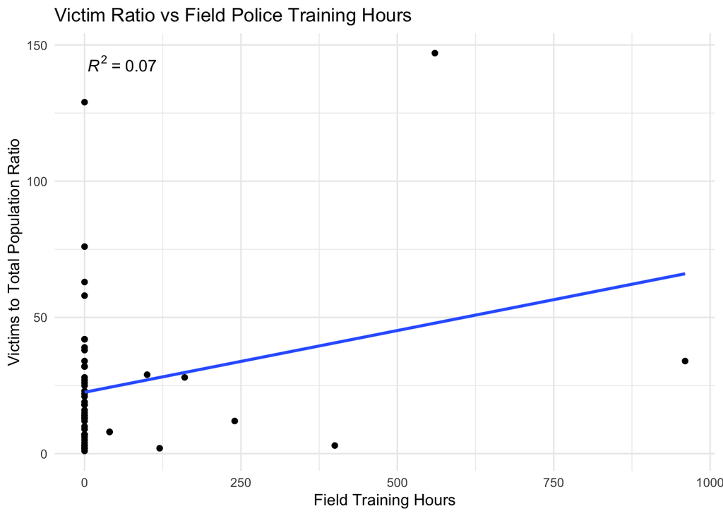

```r
#Graph
ggplot(ptmpv, aes(x = as.numeric(field_training), y = Victims)) +
  geom_point() +
  geom_smooth(method = "lm", se = FALSE, formula = y ~ x) +
  stat_poly_eq(formula = y ~ x,
               aes(label = paste(..rr.label.., sep = " ~ ")),
               parse = TRUE,
               size = 4) +
  labs(title = "Victim Ratio vs Field Police Training Hours",
       x = "Field Training Hours",
       y = "Victims to Total Population Ratio") +
  theme_minimal()
```

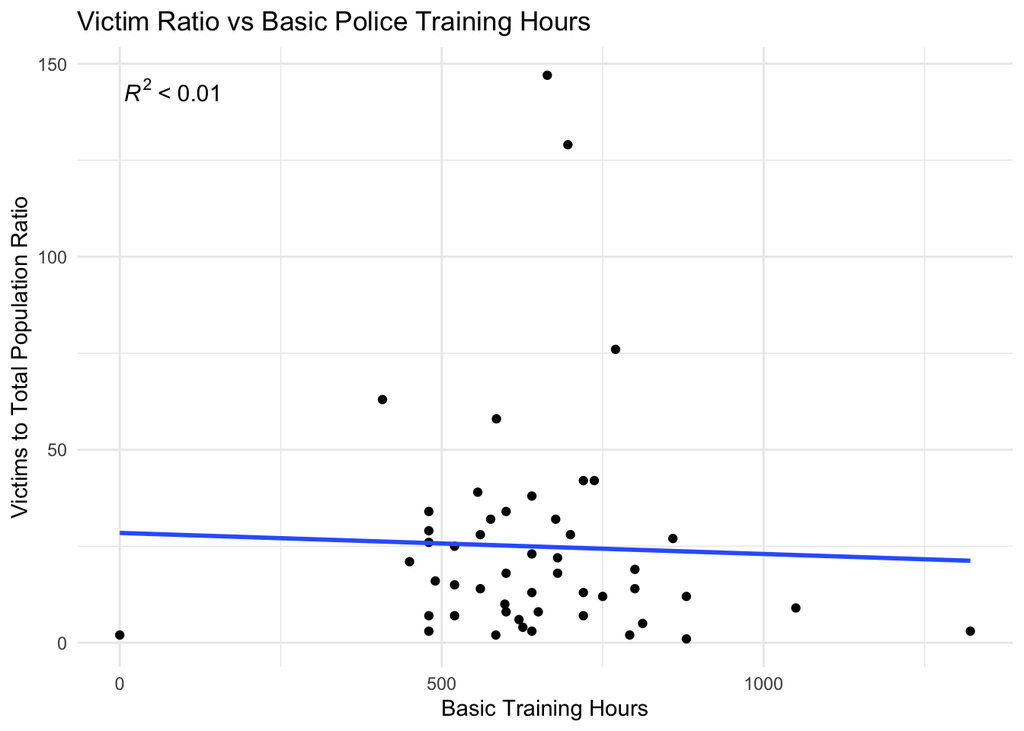

```r
#Graph
ggplot(ptmpv, aes(x = as.numeric(basic_training), y = Victims)) +
  geom_point() +
  geom_smooth(method = "lm", se = FALSE, formula = y ~ x) +
  stat_poly_eq(formula = y ~ x,
               aes(label = paste(..rr.label.., sep = " ~ ")),
               parse = TRUE,
               size = 4) +
  labs(title = "Victim Ratio vs Basic Police Training Hours",
       x = "Basic Training Hours",
       y = "Victims to Total Population Ratio") +
  theme_minimal()
```

### Figure 3 - Victim Ratio vs County Density

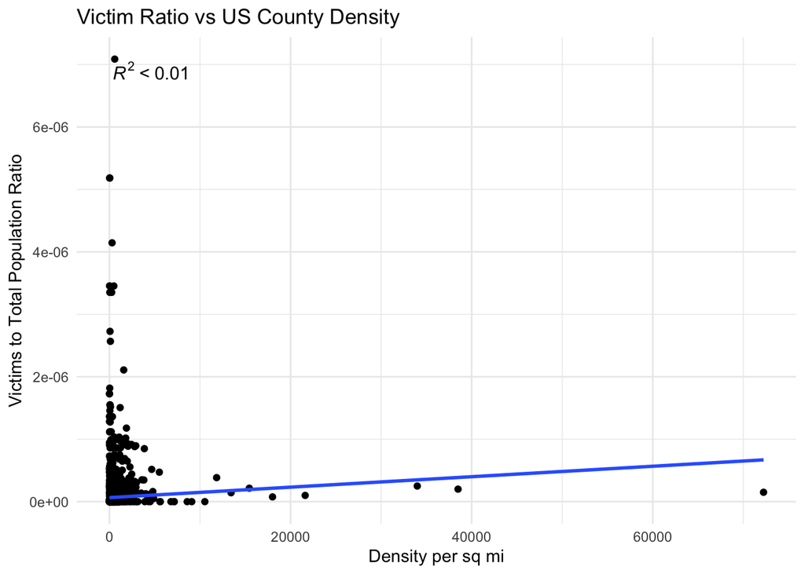

```r
# Create data table of final set for temp use
df_final_temp <- df_final %>%
  group_by(State) %>%
  mutate(total_population = sum(Population, na.rm = TRUE)) %>%
  mutate(Victims = coalesce(Victims, 0))

# Graph
ggplot(df_final_temp, aes(x = Density,
  y = Victims/df_final_temp$total_population)) +
  geom_point() +
  geom_smooth(method = "lm", se = FALSE, formula = y ~ x) +
  stat_poly_eq(formula = y ~ x,
               aes(label = paste(..rr.label.., sep = " ~ ")),
               parse = TRUE,
               size = 4) +
  labs(title = "Victim Ratio vs US County Density",
       x = "Density per sq mi",
       y = "Victims to Total Population Ratio") +
  theme_minimal()
```

### Figure 4 - Victim Ratio and County Density Category

```r
df_final_temp <- df_final %>%
  group_by(State, Density_c) %>%  # Group by both State and Density
  summarise(total_population = sum(Population, na.rm = TRUE),
            Victims = sum(coalesce(Victims, 0)))  %>%
  filter(!is.na(Density_c))
```

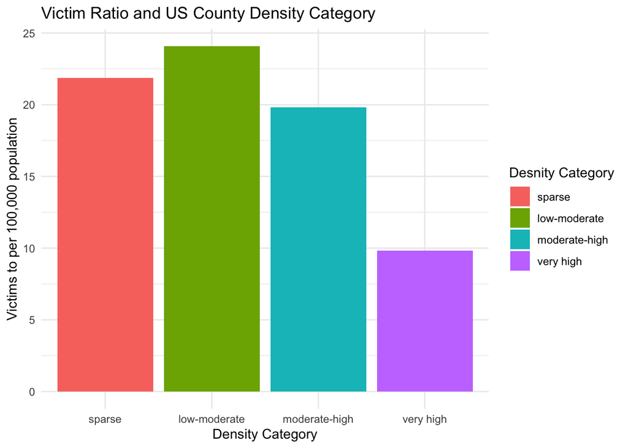

```r
# Graph with geom_bar
ggplot(df_final_temp, aes(x = Density_c,
  y = (Victims/total_population)*100000,
  fill=factor(Density_c))) +
  geom_bar(stat = "identity") +
  labs(title = "Victim Ratio and US County Density Category",
       x = "Density Category",
       y = "Victims to per 100,000 population",
       fill = "Desnity Category") +
  theme_minimal()
```

### Figure 5 - Washington Victims vs County Density

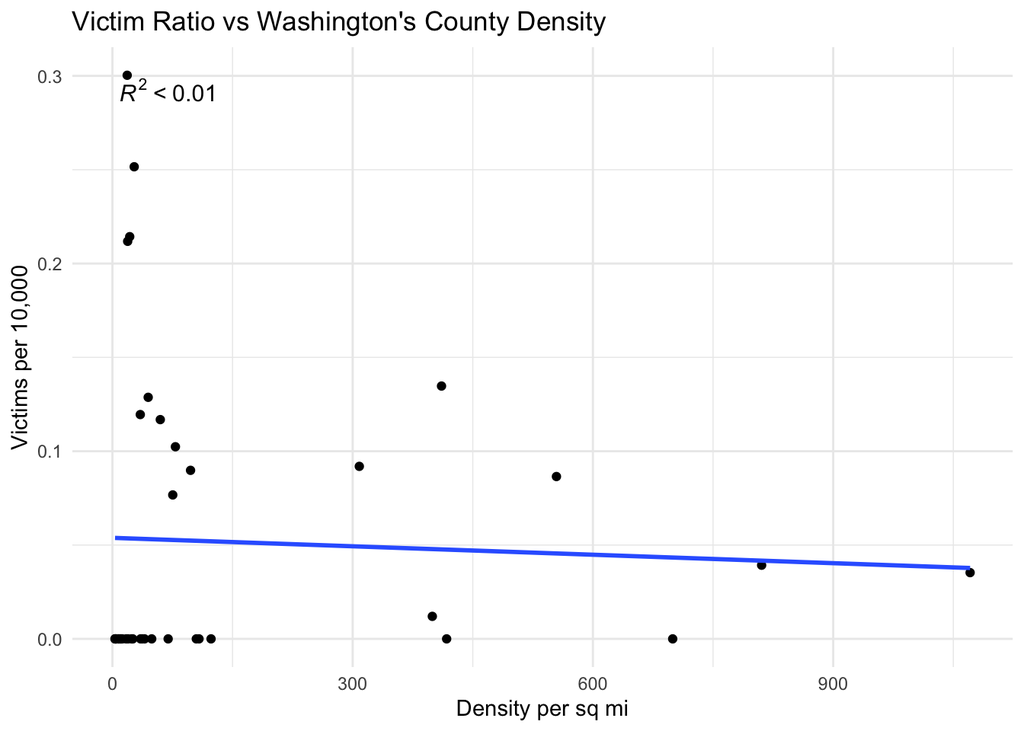

```r
# Create data table of final set for temp use
df_final_temp <- df_final %>%
  filter(State == "Washington") %>% #Change State here
  mutate(Victims = coalesce(Victims, 0))

# Graph
ggplot(df_final_temp, aes(x = Density,
  y = Victims/Population*10000)) +
  geom_point() +
  geom_smooth(method = "lm", se = FALSE, formula = y ~ x) +
  stat_poly_eq(formula = y ~ x,
               aes(label = paste(..rr.label.., sep = " ~ ")),
               parse = TRUE,
               size = 4) +
  labs(title = "Victim Ratio vs Washington's County Density",
       x = "Density per sq mi",
       y = "Victims per 10,000",
       color = "") +
  theme_minimal()
```

This figure is the same as Figure 3 but with a more specific focus on a certain state. We had the same result as Figure 3, no correlation.

### Figure 6 - State Visualization

```r
# Replace With STATE county Shapefile Folder
counties <- st_read("SHOREWA/SHOREWA")
```

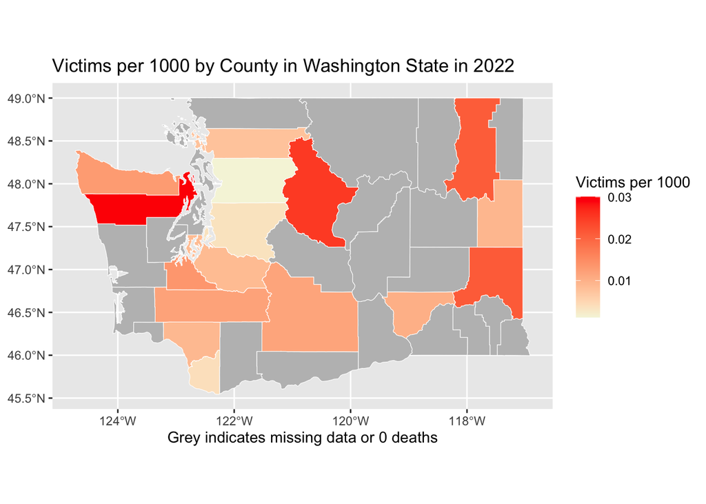

```r
df_final_temp <- df_final %>%
  filter(State == "Washington") %>%
  rename(COUNTY = County) %>%
  group_by(COUNTY) %>%
  select(COUNTY, Population, Density)

mpv_temp <- mpv %>%
  filter(State == "Washington") %>%
  rename(COUNTY = County) %>%
  group_by(COUNTY) %>%
  summarise(Victims = n()) %>%
  distinct() %>%
  ungroup()

mpv_temp <- merge(df_final_temp,mpv_temp, by="COUNTY", all=TRUE)
mpv_temp$COUNTY <- toupper(mpv_temp$COUNTY)

mpv_temp <- mpv_temp %>%
  mutate(VictimRatio = Victims/Population * 1000)

map_data <- merge(counties, mpv_temp, by.x = "COUNTY", by.y = "COUNTY", all = FALSE)
color_scale <- scale_fill_gradient(
  low = "beige",
  high = "red",
  na.value = "grey"
)

ggplot() +
  geom_sf(data = map_data, aes(fill = VictimRatio), color = "white", size = 0.2) +
  color_scale +
  labs(title = "Victims per 1000 by County in Washington State in 2022",
       fill = "Victims per 1000",
       x="Grey indicates missing data or 0 deaths")
```

This graph is a map of Washington state that shows which part Washington had police violence victims. Since some counties in Washington did not have any cases of police violence they were kept gray or were taken out of the data for the graph. But overall this graph shows what counties in Washington had the most or least police violence victims. The best thing about this is if you change the state name in the code to any state in the United States it will show you the graph/map for that state.

# **Discuss** Your Findings

**What do the results tell you regarding of your question you asked in introduction, or about the story line you want to focus on?**

[output not shown]

**What are the limitations–how far do you think you can extend your claims or story?**

```
The limitations we had with this data was that there was a lot of non-existent data for some of the counties. This affected the graphs that we outputted for some of the data because there was no point on the graph for them or they were put as 0 in the data table. I do not think that we can extend this claim or story far only due to the fact that we were unable to find clear correlation with the data sets, but if we are able to find a different data set that could potentially correlate to police violence victims then I do believe that we are able to find this claim useful.
```

**Give directions for future work–what analysis/data you might need to extend your story further?**

To extend our story further, we can explore the other categories in the Mapping to Police Violence, such as race, gender, age, and many others. We can analyze ho these factor might play into police violence cases and see if there are any correlations between them. We could also have comparison with social indicators such as social-economic status, education level, neighborhood characteristics. We could explore multiple correlations between these variables with police violence.

Something that may be interesting could be comparing these factors/results to other places around the world and why some places might have higher level of police violence than other countries.

**Takeaway Message**

When choosing these data sets we wanted to cover the issues of police violence in the different counties around the United States, more specifically Washington,and see if certain correlations could lead to more common police violence victims. We collected multiple data sources to analyze this, but we faced challenges like missing information and differences in how places are named.

With our prediction being wrong and our results surprising us, since we would think places with more people or police officers with less training would correlate with more police violence. This makes us think of other factors such as race, gender, age, economic status since our data didn’t show any correlations.

The results that we have created emphasizes that police violence is an ongoing problem that is complex in our society, and we need to be more understanding of it. We noticed and took in our limitations with our data collection, for example, missing information/values and name differences in our categories. Even though we had a difficult time comparing the data sets due to the differences between them, our results aim to help contribute to the idea of police violence